# 2 Практическая чаcть

```python
from collections import defaultdict, Counter
import copy
import os
import re
import string
import time


import pandas as pd
import numpy as np
import scipy
import matplotlib.pyplot as plt


from tqdm.notebook import trange, tqdm


import torch
from torch.autograd import Variable
from torch.utils.data import TensorDataset, DataLoader

from filimdb_evaluation.score import load_dataset_fast
```

## 2.1 Загрузка датасета.

### 1. Cоставьте таблицу, в которой указано число токенов, уникальных токенов, предложений для каждой из трех частей датасета.

```python
folder_name = './filimdb_evaluation/PTB/'
filenames = ['train', 'valid', 'test']
```

```python
def get_file_info(filename):
    global folder_name
    tokens_cnt = defaultdict(int)
    cnt_lines = 0
    with open(folder_name + f"ptb.{filename}.txt", 'r') as inp:
        for line in inp:
            cnt_lines += 1
            for token in line.strip().split():
                tokens_cnt[token] += 1
    total_tokens = sum(tokens_cnt.values())
    unique_tokens = len(tokens_cnt.keys())
    return filename, total_tokens, unique_tokens, cnt_lines, tokens_cnt

data = {
    'file':[],
    'token_cnt':[],
    'unique_tokens':[],
    'sentences_cnt': []
}

file_dicts = []

for f in filenames:
    f_data = get_file_info(f)
    data['file'].append(f_data[0])
    data['token_cnt'].append(f_data[1])
    data['unique_tokens'].append(f_data[2])
    data['sentences_cnt'].append(f_data[3])
    file_dicts.append(f_data[4])

all_tokens = defaultdict(int)
for d in file_dicts:
    for k, v in d.items():
        all_tokens[k] += v

data['file'].append('all files')
data['token_cnt'].append(sum(data['token_cnt']))
data['unique_tokens'].append(len(all_tokens.keys()))
data['sentences_cnt'].append(sum(data['sentences_cnt']))

df = pd.DataFrame(data=data)
df
```

|  | file | token_cnt | unique_tokens | sentences_cnt |
| --- | --- | --- | --- | --- |
| 0 | train | 887521 | 9999 | 42068 |
| 1 | valid | 70390 | 6021 | 3370 |
| 2 | test | 78669 | 6048 | 3761 |
| 3 | all files | 1036580 | 9999 | 49199 |

### 2. Приведите 10 самых частотных и 10 самых редких токенов с их частотами.

(тут видимо для всех файлов)

```python
tokens_cnt = defaultdict(int)
for f in filenames:
     with open(folder_name + f"ptb.{f}.txt", 'r') as inp:
        for line in inp:
            for token in line.strip().split():
                tokens_cnt[token] += 1
cnt_list = list(tokens_cnt.items())
cnt_list.sort(key=lambda x: x[1])
most_frequent_data = {'word':[], 'cnt':[]}
for w, c in cnt_list[-10:][::-1]:
    most_frequent_data['word'].append(w)
    most_frequent_data['cnt'].append(c)
least_frequent_data = {'word':[], 'cnt':[]}
for w, c in cnt_list[:10]:
    least_frequent_data['word'].append(w)
    least_frequent_data['cnt'].append(c)
```

```python
pd.DataFrame(data=most_frequent_data)
```

|  | word | cnt |
| --- | --- | --- |
| 0 | the | 59421 |
| 1 | <unk> | 53299 |
| 2 | N | 37607 |
| 3 | of | 28427 |
| 4 | to | 27430 |
| 5 | a | 24755 |
| 6 | in | 21032 |
| 7 | and | 20404 |
| 8 | 's | 11555 |
| 9 | for | 10436 |

```python
pd.DataFrame(data=least_frequent_data)
```

|  | word | cnt |
| --- | --- | --- |
| 0 | buffet | 5 |
| 1 | lancaster | 5 |
| 2 | barnett | 5 |
| 3 | rewrite | 5 |
| 4 | downgrading | 5 |
| 5 | backgrounds | 5 |
| 6 | stanza | 5 |
| 7 | vessel | 5 |
| 8 | unstable | 5 |
| 9 | peat | 5 |

### 3. Какие специальные токены уже есть в выборке, что они означают?

Вроде как, токены выглядят как текст в треугольных кавычках. Поищем такие фрагменты.

```python
spec_tokens = set()
for f in filenames:
     with open(folder_name + f"ptb.{f}.txt", 'r') as inp:
        for line in inp:
            cur_spec = set(re.findall(r'<[a-z]*>', line))
            spec_tokens = spec_tokens.union(cur_spec)
print(spec_tokens)
```

```
{'<unk>'}
```

Этим токеном заменяются слова, невошедшие в 10000 самых популярных в корпусе.

Также есть специальные токены вида:

1. N - все отдельно стоящие числа заменяются на этот токен.
2. \$ - на этот токен заменяются все знаки валют.

## 2.2 Генерацей батчей.

Тут написана версия разбиения на батчи для для слов в обычном виде, чтобы проще было проверить правильность построения. Сильно ниже будет версия генератора для уже приведенных к индексам слов в предложении.

```python
def print_batch(ind, X_b, Y_b):
    print(f"Batch # {ind}")
    for i in range(len(X_b)):
            print(X_b[i], ' ', Y_b[i])
```

```python
def batch_generator_text(data_path, batch_size, num_steps, debug=False):
    eos_token = '<eos>'
    L_tokens = []
    with open(data_path, 'r', encoding='utf-8') as inp:
        for line in inp:
            line_tokens = list(map(str.lower, line.strip().split()))
            L_tokens.extend(line_tokens + [eos_token])

    L_shifted = L_tokens[1:]
    L_tokens = L_tokens[:-1]
    print(len(L_tokens), len(L_shifted))
    slice_len = len(L_tokens) // batch_size
    X_lists = [L_tokens[i * slice_len : (i + 1) * slice_len] for i in range(batch_size)]
    Y_lists = [L_shifted[i * slice_len : (i + 1) * slice_len] for i in range(batch_size)]

    total_batchs = slice_len // num_steps
    for i in range(total_batchs):
        X_batch = []
        Y_batch = []
        for lst in X_lists:
            X_batch.append(lst[i * num_steps : (i + 1) * num_steps])
        for lst in Y_lists:
            Y_batch.append(lst[i * num_steps : (i + 1) * num_steps])
        if debug and i < 3:
            print_batch(i, X_batch, Y_batch)
#         yield torch.tensor(X_batch, requires_grad=False), torch.tensor(Y_batch, requires_grad=False)

res = batch_generator_text(folder_name + "ptb.train.txt", batch_size = 2, num_steps = 3, debug=True)
```

```
929588 929588
Batch # 0
['aer', 'banknote', 'berlitz']   ['banknote', 'berlitz', 'calloway']
['guarantee', 'the', 'government']   ['the', 'government', 'can']
Batch # 1
['calloway', 'centrust', 'cluett']   ['centrust', 'cluett', 'fromstein']
['can', 'ensure', 'the']   ['ensure', 'the', 'same']
Batch # 2
['fromstein', 'gitano', 'guterman']   ['gitano', 'guterman', 'hydro-quebec']
['same', 'flow', 'of']   ['flow', 'of', 'resources']
```

## 2.3 Реализация LSTM LM.

### 2.3.1 Класс LSTMCell

Для реализации LSTM ячейки будем отталкиваться от реализации обычной RNN ячейки из семинара.

```python
class LSTMCell(torch.nn.Module):
    def __init__(self, input_size, hidden_size):
        '''
        Args:
            input_size: Size of token embedding
            hidden_size: Size of hidden state of LSTM cell
        '''
        super(LSTMCell, self).__init__()
        self.input_size = input_size
        self.hidden_size = hidden_size

        # Creating matrices whose weights will be trained
        # Token embedding (input of this cell) will be multiplied by this matrix
        self.U_input = torch.nn.Parameter(torch.Tensor(input_size, 4 * hidden_size))
        self.BU_input = torch.nn.Parameter(torch.Tensor(4 * hidden_size))

        # Creating matrices whose weights will be trained
        # Hidden state from previous step will be multipied by this matrix
        # Zero hidden state at the initial step
        self.W_hidden = torch.nn.Parameter(torch.Tensor(hidden_size, 4 * hidden_size))
        self.BW_hidden = torch.nn.Parameter(torch.Tensor(4 * hidden_size))

        # Weights initialization
        self.reset_parameters()

    def forward(self, inp: torch.Tensor, cell_state: torch.Tensor, hidden_state: torch.Tensor) -> (torch.Tensor, torch.Tensor):
        '''
        Performes forward pass of the recurrent cell
        Args:
            inp: Output from Embedding layer at the current timestep
                Tensor shape is (batch_size, emb_size)
            cell_state: Output cell_state from previous recurrent step or zero state
                Tensor shape is (batch_size, hidden_size)
            hidden_state: Output hidden_state from previous recurrent step or zero state
                Tensor shape is (batch_size, hidden_size)
        Returns:
            Output from LSTM cell
        '''
        hidden_mult = hidden_state @ self.W_hidden + self.BW_hidden
        input_mult  = inp @ self.U_input + self.BU_input
        matr_sum = input_mult + hidden_mult

        f, i, c_new, o, = matr_sum.chunk(chunks=4, dim=1)
        f = torch.sigmoid(f)
        i = torch.sigmoid(i)
        c_new = torch.tanh(c_new)
        o = torch.sigmoid(o)

        cell_state_new = cell_state * f + i * c_new
        hidden_state_new = o * torch.tanh(cell_state_new)

        return cell_state_new, hidden_state_new

    def reset_parameters(self):
        '''
        Weights initialization
        '''
        stdv = 1.0 / np.sqrt(self.hidden_size)
        for weight in self.parameters():
            torch.nn.init.uniform_(weight, -stdv, stdv)
```

8 матриц и векторов смещений заменили на 2 каждого вида.  
Всё перемножили и сложили по формулам, применили функции активация к каждой из 4 частей большой матрицы.  
Дальше осталось просто всё правильно поэлементно перемножить и получить новые состояния ячейки и скрытое состояние.

### 2.3.2 Класс LSTMLayer

```python
class LSTMLayer(torch.nn.Module):
    def __init__(self, emb_size, hidden_size):
        super(LSTMLayer, self).__init__()
        self.input_size = emb_size
        self.hidden_size = hidden_size
        self.LSTMCell = LSTMCell(emb_size, hidden_size)

    def forward(self, X_batch, initial_states):
        cell_state, hidden_state = initial_states
        outputs = []
        for timestamp in range(X_batch.shape[0]):
            cell_state, hidden_state = self.LSTMCell(X_batch[timestamp], cell_state, hidden_state)
            outputs.append(hidden_state)
        return torch.stack(outputs), (cell_state, hidden_state)
```

### 2.3.3 Класс LSTM

```python
class LSTM(torch.nn.Module):
    def __init__(self, emb_size, hidden_size, num_layers, dropout_rate):
        super(LSTM, self).__init__()
        self.input_size = emb_size
        self.hidden_size = hidden_size
        self.num_layers = num_layers
        self.dropout_rate = dropout_rate

        self.layers = []
        for i in range(num_layers):
            self.layers.append(torch.nn.Dropout(p=self.dropout_rate))
            if i == 0:
                self.layers.append(LSTMLayer(emb_size, hidden_size))
            else:
                self.layers.append(LSTMLayer(hidden_size, hidden_size))

        self.layers.append(torch.nn.Dropout(p=self.dropout_rate))
        self.layers = torch.nn.ModuleList(self.layers)

    def forward(self, X_batch, initial_states):
        for ind, layer in enumerate(self.layers):
            if ind % 2 == 1:
                X_batch, states = layer(X_batch, initial_states)
            else:
                X_batch = layer(X_batch)
        return X_batch, states
```

### 2.3.4 Класс PTBLM

```python
class PTBLM(torch.nn.Module):
    def __init__(self, num_layers, emb_size, hidden_size, vocab_size, dropout_rate, weight_init=0.1, tie_emb=True, adaptive=False):
        super(PTBLM, self).__init__()
        self.num_layers = num_layers
        self.input_size = emb_size
        self.hidden_size = hidden_size
        self.vocab_size = vocab_size
        self.dropout_rate = dropout_rate
        self.weight_max = weight_init
        self.tie = tie_emb
        self.adaptive = adaptive


        self.embedding = torch.nn.Embedding(num_embeddings=vocab_size, embedding_dim=emb_size)
        self.LSTM = LSTM(emb_size, hidden_size, num_layers, dropout_rate)
        self.decoder = torch.nn.Linear(in_features=hidden_size, out_features=vocab_size)
        self.tie_b =  torch.nn.Parameter(torch.zeros(vocab_size))

        self.adaptive_sm = torch.nn.AdaptiveLogSoftmaxWithLoss(self.hidden_size, self.vocab_size, cutoffs=[500, 2000, 10000])

        self.sentiment_decoder = torch.nn.Linear(in_features=self.hidden_size, out_features=2)

        self.init_weights()


    def forward(self, model_input, initial_states, target=None):
        embs = self.embedding(model_input).transpose(0, 1).contiguous()

        outputs, states = self.LSTM(embs, initial_states)

        if self.adaptive:
            outputs = outputs.transpose(0, 1).contiguous()
            out, loss = self.adaptive_sm(outputs.view(-1, self.hidden_size), target.view(-1))
            return out, loss, states

        # print(outputs.shape)
        if self.tie:
            ns, bs = outputs.shape[0], outputs.shape[1]
            outputs = outputs.view(-1, self.hidden_size)
            logits = outputs.mm(self.embedding.weight.t()) + self.tie_b
            logits = logits.view(ns, bs, self.vocab_size)
        else:
            logits = self.decoder(outputs)

        logits = logits.transpose(0, 1).contiguous()

        return logits, states

    def forward_classify(self, batch_texts, text_lenghts, initial_states):
        """
            model_input: batch of indexed tests
            text_lenghts: lenght of examples in batch
            initial_states: states for lstm layers
        """
        embs = self.embedding(batch_texts).transpose(0, 1).contiguous()

        outputs, states = self.LSTM(embs, initial_states)
        # outputs.shape = (max_len, bs, hidden_size)

        max_len, bs = outputs.shape[0], outputs.shape[1]
        outputs = outputs.transpose(0, 1).contiguous()
        # outputs.shape = (bs, max_len, hidden_size)

        # Getting last non pad output vector
        outputs = outputs[np.arange(outputs.shape[0]), text_lenghts]
        #outputs.shape = (bs, hidden_size)

#         print(outputs.shape)

        logits = self.sentiment_decoder(outputs)

        return logits, states

    def init_weights(self):
        self.embedding.weight.data.uniform_(-self.weight_max, self.weight_max)
        self.decoder.weight.data.uniform_(-self.weight_max, self.weight_max)
        torch.nn.init.uniform_(self.tie_b, -self.weight_max, self.weight_max)

    def init_hidden(self, batch_size, device):
        return torch.zeros(batch_size, self.hidden_size).to(device), torch.zeros(batch_size, self.hidden_size).to(device)
```

## 2.4 Обучение языковой модели.

Ниже функции для подготовки ptb датасета и словарей.

```python
START_TOKEN =  '<start>'
EOS_TOKEN =  '<eos>'
```

```python
def _read_words(path):
    with open(path, 'r') as inp:
        names = inp.read().lower().split()
        return names
print(_read_words(folder_name + 'small.txt'))
```

```
['pierre', '<unk>', 'n', 'years', 'old', 'will', 'join', 'the', 'board', 'as', 'a', 'nonexecutive', 'director', 'nov.', 'n', 'mr.', '<unk>', 'is', 'chairman', 'of', '<unk>', 'n.v.', 'the', 'dutch', 'publishing', 'group', 'rudolph', '<unk>', 'n', 'years', 'old', 'and', 'former', 'chairman', 'of', 'co…
```

```python
def _read_sentences(path):
    with open(path, 'r') as inp:
        sentences = inp.read().lower().split('\n')
    sentences = [[START_TOKEN] + sent.split() for sent in sentences]
    return sentences

sents = _read_sentences(folder_name + 'small.txt')
for sent in sents:
    print(sent)
```

```
['<start>', 'pierre', '<unk>', 'n', 'years', 'old', 'will', 'join', 'the', 'board', 'as', 'a', 'nonexecutive', 'director', 'nov.', 'n']
['<start>', 'mr.', '<unk>', 'is', 'chairman', 'of', '<unk>', 'n.v.', 'the', 'dutch', 'publishing', 'group']
['<start>', 'rudolph', '<unk>', 'n', 'years', 'old', 'and', 'former', 'chairman', 'of', 'consolidated', 'gold', 'fields', 'plc', 'was', 'named', 'a', 'nonexecutive', 'director', 'of', 'this', 'british', 'industrial', 'conglomerate']
```

```python
def _build_vocab(path):
    data = _read_words(path)
    special_tokens = [START_TOKEN, EOS_TOKEN]
    data += special_tokens

    counter = Counter(data)
    sorted_words = sorted(counter.items(), key=lambda x: -x[1])

    words = [w for w, _ in sorted_words]
    word_to_id = dict(zip(words, range(len(words))))
    id_to_word = {v: k for k, v in word_to_id.items()}

    return word_to_id, id_to_word

word_to_id, id_to_word = _build_vocab(folder_name + 'small.txt')
print('Vocab size = ', len(word_to_id))
print(list(word_to_id.items()))
```

```
Vocab size =  37
[('<unk>', 0), ('n', 1), ('of', 2), ('years', 3), ('old', 4), ('the', 5), ('a', 6), ('nonexecutive', 7), ('director', 8), ('chairman', 9), ('pierre', 10), ('will', 11), ('join', 12), ('board', 13), ('as', 14), ('nov.', 15), ('mr.', 16), ('is', 17), ('n.v.', 18), ('dutch', 19), ('publishing', 20), ('…
```

```python
def _sentences_to_word_ids(word_to_id, texts = None, path=None):
    if path is not None:
        sentences = _read_sentences(path)
    elif texts is not None:
        sentences = texts
    return [[word_to_id[word] for word in sent] for sent in sentences]

word_to_id, id_to_word = _build_vocab(folder_name + 'small.txt')
res = _sentences_to_word_ids(word_to_id, path = folder_name + 'small.txt',)
for sent in res:
    print(sent)
```

```
[35, 10, 0, 1, 3, 4, 11, 12, 5, 13, 14, 6, 7, 8, 15, 1]
[35, 16, 0, 17, 9, 2, 0, 18, 5, 19, 20, 21]
[35, 22, 0, 1, 3, 4, 23, 24, 9, 2, 25, 26, 27, 28, 29, 30, 6, 7, 8, 2, 31, 32, 33, 34]
```

```python
def ptb_raw_data(data_path, debug=False):
    train_path = os.path.join(data_path, 'ptb.train.txt')
    dev_path = os.path.join(data_path, 'ptb.valid.txt')
    test_path = os.path.join(data_path, 'ptb.test.txt')

    word_to_id, id_to_word = _build_vocab(train_path)
    train_data = _sentences_to_word_ids(word_to_id, path=train_path)
    dev_data = _sentences_to_word_ids(word_to_id, path=dev_path)
    test_data = _sentences_to_word_ids(word_to_id, path=test_path)

    return train_data, dev_data, test_data, word_to_id, id_to_word

train_data, dev_data, test_data, word_to_ind, ind_to_word = ptb_raw_data(folder_name)
print('Vocab size = ', len(word_to_ind))
for sent in train_data[:5]:
    print(sent)
```

```
Vocab size =  10001
[9999, 9969, 9970, 9971, 9972, 9973, 9974, 9975, 9976, 9977, 9978, 9979, 9980, 9981, 9982, 9983, 9984, 9985, 9986, 9987, 9988, 9989, 9990, 9991, 9992]
[9999, 8568, 1, 2, 71, 392, 32, 2115, 0, 145, 18, 5, 8569, 274, 406, 2]
[9999, 22, 1, 12, 140, 3, 1, 5277, 0, 3054, 1580, 95]
[9999, 7231, 1, 2, 71, 392, 7, 336, 140, 3, 2467, 656, 2157, 948, 23, 520, 5, 8569, 274, 3, 38, 302, 436, 3660]
[9999, 5, 940, 3, 3142, 494, 261, 4, 136, 5881, 4218, 5882, 29, 985, 5, 239, 754, 3, 1012, 2764, 210, 5, 95, 3, 426, 4059, 4, 13, 44, 54, 2, 71, 194, 1232, 219]
```

```python
def batch_generator_inds(data, word_to_id, batch_size, num_steps, debug=False):
    L_tokens = []
    for sentence in data:
        L_tokens.extend(sentence + [word_to_id[EOS_TOKEN]])
    L_shifted = L_tokens[1:]
    L_tokens = L_tokens[:-1]

    slice_len = len(L_tokens) // batch_size
    X_lists = [L_tokens[i * slice_len : (i + 1) * slice_len] for i in range(batch_size)]
    Y_lists = [L_shifted[i * slice_len : (i + 1) * slice_len] for i in range(batch_size)]
    # print(len(X_lists))

    total_batchs = slice_len // num_steps
    for i in range(total_batchs):
        X_batch = []
        Y_batch = []
        for lst in X_lists:
            X_batch.append(lst[i * num_steps : (i + 1) * num_steps])
        for lst in Y_lists:
            Y_batch.append(lst[i * num_steps : (i + 1) * num_steps])
        if debug:
            print_batch(i, X_batch, Y_batch)
        else:
            if X_batch:
                yield torch.tensor(X_batch, requires_grad=False), torch.tensor(Y_batch, requires_grad=False)

train_data, dev_data, test_data, word_to_ind, ind_to_word = ptb_raw_data(folder_name, debug=True)
res = batch_generator_inds(train_data, word_to_ind, batch_size = 2, num_steps = 3)
next(res)
```

```
(tensor([[9999, 9969, 9970],
         [   4, 2818,  507]]),
 tensor([[9969, 9970, 9971],
         [2818,  507,   35]]))
```

Теперь перейдем к функциям для обучения сети.

```python
def update_lr(optimizer, lr):
    for g in optimizer.param_groups:
        g['lr'] = lr

def run_epoch(
    lr,
    model,
    data,
    word_to_id,
    loss_fn,
    batch_size,
    num_steps,
    optimizer = None,
    clip_value = None,
    device = None
) -> float:
    '''
    Performs one training epoch or inference epoch
    Args:
        lr: Learning rate for this epoch
        model: Language model object
        data: Data that will be passed through the language model
        char_to_id: Mapping of each character into its index in the vocabulary
        loss_fn: Torch loss function
        optimizer: Torch optimizer
        device: Input tensors should be sent to this device
    Returns:
        Perplexity
    '''

    total_loss, total_examples = 0.0, 0
    generator = batch_generator_inds(data, word_to_id=word_to_id, batch_size=batch_size, num_steps=num_steps)

    initial_state = model.init_hidden(batch_size=batch_size, device=device)
    for step, (X, Y) in enumerate(generator):
        X = X.to(device)
        Y = Y.to(device)

        if model.adaptive:
            out, loss, new_state = model(X, initial_state, target=Y)
        else:
            logits, new_state = model(X, initial_state)
        initial_state = (new_state[0].detach(), new_state[1].detach())

        if model.adaptive:
            total_examples += out.shape[0]
            total_loss += loss.item() * out.shape[0]
        else:
            loss = loss_fn(logits.view((-1, model.vocab_size)), Y.view(-1))
            total_examples += loss.size(0)
            total_loss += loss.sum().item()
            loss = loss.mean()


        # Gradients computation
        if optimizer is not None:
            loss.backward()

#             print("------------------------------------------")
#             print("CHECK GRADS")
#             for p in list(filter(lambda p: p.grad is not None, model.parameters())):
#                 print(p.grad.data.norm(2).item())
#             print("------------------------------------------")


            # We have a new learning rate value at every step, so it needs to be updated
            update_lr(optimizer, lr)

            # Gradient clipping by predefined norm value - usually 5.0
            if clip_value is not None:
                torch.nn.utils.clip_grad_norm_(model.parameters(), clip_value)

            # Applying gradients - one gradient descent step
            optimizer.step()
            optimizer.zero_grad()

    return np.exp(total_loss / total_examples)
```

```python
base_config = {
        'batch_size': 64, 'num_steps': 35,
        'num_layers': 2, 'emb_size': 256,
        'hidden_size': 256, 'vocab_size': -1,
        'dropout_rate': 0.2, 'num_epochs': 13,
        'learning_rate': 0.01, 'lr_decay' : 0.9,
        'epoch_decay' : 6, 'tied_embs': False,
        'weight_init':0.1, 'grad_clipping' : None,
        'optimizer' : 'Adam'
}
```

```python
raw_data = ptb_raw_data(folder_name)
train_data, dev_data, test_data, word_to_id, id_to_word = raw_data
base_config['vocab_size'] = len(word_to_id)
base_config['vocab_size']
```

```
10001
```

наконец-то функция для тестировочного обучения

```python
def train_on_config(cur_config, train_data, dev_data, test_data):
    model = PTBLM(num_layers=cur_config['num_layers'], emb_size=cur_config['emb_size'],
              hidden_size=cur_config['hidden_size'], vocab_size=cur_config['vocab_size'],
              dropout_rate=cur_config['dropout_rate'], weight_init=cur_config['weight_init'],
              tie_emb=cur_config['tied_embs'],
             )
    print(model)
    device = torch.device("cuda:0" if torch.cuda.is_available() else "cpu")
    print("Training on device: ", device)
    model.to(device)
    loss_fn = torch.nn.CrossEntropyLoss(reduction='none')
    if cur_config['optimizer'] == 'Adam':
        optimizer = torch.optim.Adam(model.parameters(), lr=cur_config['learning_rate'])
    elif cur_config['optimizer'] == 'SGD':
        optimizer = torch.optim.SGD(model.parameters(), lr=cur_config['learning_rate'])
    else:
        optimizer = torch.optim.SGD(model.parameters(), lr=cur_config['learning_rate'], momentum=0.8)
    plot_data = [[], []]
    for i in trange(cur_config['num_epochs']):
        lr_decay = cur_config['lr_decay'] ** max(i + 1 - cur_config['epoch_decay'], 0.0)
        if cur_config['lr_decay'] > 1:
            lr_decay = 1 / lr_decay
        decayed_lr = cur_config['learning_rate'] * lr_decay

        model.train()
        train_perplexity = run_epoch(decayed_lr, model, train_data,
                                     word_to_id, loss_fn,
                                     cur_config['batch_size'], cur_config['num_steps'],
                                     optimizer=optimizer,
                                     clip_value=cur_config['grad_clipping'],
                                     device=device)

        model.eval()

        # Disabling gradient calculation.
        # It will reduce memory consumption for computations
        # The result of every computation will have requires_grad=False,
        with torch.no_grad():
            dev_perplexity = run_epoch(decayed_lr, model, dev_data,
                                       word_to_id, loss_fn, cur_config['batch_size'], cur_config['num_steps'],
                                       device=device)

        plot_data[0].append(train_perplexity)
        plot_data[1].append(dev_perplexity)
        print(f'Epoch: {i+1}. Learning rate: {decayed_lr:.3f}. '
              f'Train Perplexity: {train_perplexity:.3f}. '
              f'Dev Perplexity: {dev_perplexity:.3f}. '
             )

    model.eval()
    with torch.no_grad():
        test_perplexity = run_epoch(
            decayed_lr, model, test_data,
            word_to_id, loss_fn, cur_config['batch_size'], cur_config['num_steps'],
            device=device)
        print(f"Test Perplexity: {test_perplexity:.3f}")

    return model, plot_data
```

```python
base_model, base_train_data = train_on_config(base_config, train_data, dev_data, test_data)
```

```
PTBLM(
  (embedding): Embedding(10001, 256)
  (LSTM): LSTM(
    (layers): ModuleList(
      (0): Dropout(p=0.2, inplace=False)
      (1): LSTMLayer(
        (LSTMCell): LSTMCell()
      )
      (2): Dropout(p=0.2, inplace=False)
      (3): LSTMLayer(
        (LSTMCell): LSTMCell()
      )
      (4): Dropout(p=0.2, inplace=False)
    )
  )
  (decoder): Linear(in_features=256, out_features=10001, bias=True)
  (adaptive_sm): AdaptiveLogSoftmaxWithLoss(
    (head): Linear(in_features=256, out_features=503, bias=False)
    (tail): ModuleList(
      (0): Sequential(
        (0): Linear(in_features=256, out_features=64, bias=False)
        (1): Linear(in_features=64, out_features=1500, bias=False)
      )
      (1): Sequential(
        (0): Linear(in_features=256, out_features=16, bias=False)
        (1): Linear(in_features=16, out_features=8000, bias=False)
      )
      (2): Sequential(
        (0): Linear(in_features=256, out_features=4, bias=False)
        (1): Linear(in_features=4, out_features=1, bias=False)
      )
    )
  )
  (sentiment_decoder): Linear(in_features=256, out_features=2, bias=True)
)
Training on device:  cuda:0
```

```
Epoch: 1. Learning rate: 0.010. Train Perplexity: 348.177. Dev Perplexity: 200.924.
Epoch: 2. Learning rate: 0.010. Train Perplexity: 180.191. Dev Perplexity: 153.685.
Epoch: 3. Learning rate: 0.010. Train Perplexity: 137.892. Dev Perplexity: 138.730.
Epoch: 4. Learning rate: 0.010. Train Perplexity: 117.969. Dev Perplexity: 135.068.
Epoch: 5. Learning rate: 0.010. Train Perplexity: 105.617. Dev Perplexity: 129.934.
Epoch: 6. Learning rate: 0.010. Train Perplexity: 97.422. Dev Perplexity: 127.332.
Epoch: 7. Learning rate: 0.009. Train Perplexity: 89.902. Dev Perplexity: 125.433.
Epoch: 8. Learning rate: 0.008. Train Perplexity: 83.761. Dev Perplexity: 126.054.
Epoch: 9. Learning rate: 0.007. Train Perplexity: 78.708. Dev Perplexity: 122.514.
Epoch: 10. Learning rate: 0.007. Train Perplexity: 74.587. Dev Perplexity: 124.048.
Epoch: 11. Learning rate: 0.006. Train Perplexity: 70.950. Dev Perplexity: 124.801.
Epoch: 12. Learning rate: 0.005. Train Perplexity: 67.971. Dev Perplexity: 126.628.
Epoch: 13. Learning rate: 0.005. Train Perplexity: 65.380. Dev Perplexity: 128.310.
Test Perplexity: 116.980
```

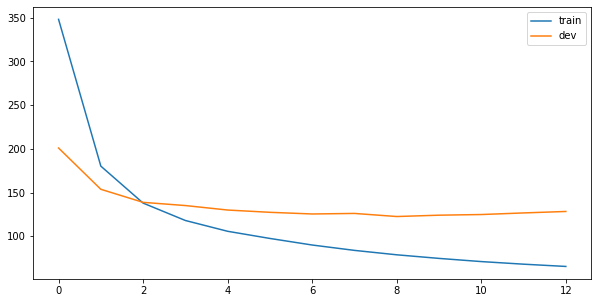

```python
fig = plt.figure(figsize=(10, 5))
ax = fig.add_subplot(111)
ax.plot(base_train_data[0], label='train')
ax.plot(base_train_data[1], label='dev')
ax.legend()
plt.show()
```

Сеть обученная выше наиболее похожа на самую маленькую, представленную в статье Zaremba.  
Отметим, что среднюю сеть из статьи не получается обучать на Adam, потому что-то там происходит что-то неадекватное с градиентами и лоссом.  
Поэтому возвращаем SGD и пробуем обучить среднюю сеть.

```python
medium_config = {
        'batch_size': 20, 'num_steps': 35,
        'num_layers': 2, 'emb_size': 650,
        'hidden_size': 650, 'vocab_size': 10001,
        'dropout_rate': 0.5, 'num_epochs': 39,
        'learning_rate': 1.0, 'lr_decay' : 0.8,
        'epoch_decay' : 10, 'tied_embs': False,
        'weight_init': 0.05, 'grad_clipping' : 5,
        'optimizer' : 'SGD'
         }
```

```python
medium_model, medium_train_data = train_on_config(medium_config)
```

```
PTBLM(
  (embedding): Embedding(10001, 650)
  (LSTM): LSTM(
    (layers): ModuleList(
      (0): Dropout(p=0.5, inplace=False)
      (1): LSTMLayer(
        (LSTMCell): LSTMCell()
      )
      (2): Dropout(p=0.5, inplace=False)
      (3): LSTMLayer(
        (LSTMCell): LSTMCell()
      )
      (4): Dropout(p=0.5, inplace=False)
    )
  )
  (decoder): Linear(in_features=650, out_features=10001, bias=True)
)
Training on device:  cuda:0
```

```
Epoch: 1. Learning rate: 1.000. Train Perplexity: 633.883. Dev Perplexity: 439.388.
Epoch: 2. Learning rate: 1.000. Train Perplexity: 372.538. Dev Perplexity: 314.932.
Epoch: 3. Learning rate: 1.000. Train Perplexity: 302.003. Dev Perplexity: 272.168.
Epoch: 4. Learning rate: 1.000. Train Perplexity: 257.440. Dev Perplexity: 237.747.
Epoch: 5. Learning rate: 1.000. Train Perplexity: 217.215. Dev Perplexity: 198.726.
Epoch: 6. Learning rate: 1.000. Train Perplexity: 188.994. Dev Perplexity: 175.633.
Epoch: 7. Learning rate: 1.000. Train Perplexity: 169.267. Dev Perplexity: 160.579.
Epoch: 8. Learning rate: 1.000. Train Perplexity: 154.120. Dev Perplexity: 149.544.
Epoch: 9. Learning rate: 1.000. Train Perplexity: 142.161. Dev Perplexity: 141.131.
Epoch: 10. Learning rate: 1.000. Train Perplexity: 132.170. Dev Perplexity: 133.325.
Epoch: 11. Learning rate: 0.800. Train Perplexity: 122.400. Dev Perplexity: 126.713.
Epoch: 12. Learning rate: 0.640. Train Perplexity: 115.275. Dev Perplexity: 121.686.
Epoch: 13. Learning rate: 0.512. Train Perplexity: 109.875. Dev Perplexity: 118.061.
Epoch: 14. Learning rate: 0.410. Train Perplexity: 105.643. Dev Perplexity: 115.229.
Epoch: 15. Learning rate: 0.328. Train Perplexity: 102.198. Dev Perplexity: 113.077.
Epoch: 16. Learning rate: 0.262. Train Perplexity: 99.618. Dev Perplexity: 111.438.
Epoch: 17. Learning rate: 0.210. Train Perplexity: 97.634. Dev Perplexity: 110.168.
Epoch: 18. Learning rate: 0.168. Train Perplexity: 95.863. Dev Perplexity: 109.082.
Epoch: 19. Learning rate: 0.134. Train Perplexity: 94.615. Dev Perplexity: 108.523.
Epoch: 20. Learning rate: 0.107. Train Perplexity: 93.585. Dev Perplexity: 107.471.
Epoch: 21. Learning rate: 0.086. Train Perplexity: 92.775. Dev Perplexity: 106.965.
Epoch: 22. Learning rate: 0.069. Train Perplexity: 92.068. Dev Perplexity: 106.601.
Epoch: 23. Learning rate: 0.055. Train Perplexity: 91.824. Dev Perplexity: 106.286.
Epoch: 24. Learning rate: 0.044. Train Perplexity: 91.313. Dev Perplexity: 105.863.
Epoch: 25. Learning rate: 0.035. Train Perplexity: 90.958. Dev Perplexity: 105.679.
Epoch: 26. Learning rate: 0.028. Train Perplexity: 90.784. Dev Perplexity: 105.366.
Epoch: 27. Learning rate: 0.023. Train Perplexity: 90.522. Dev Perplexity: 105.333.
Epoch: 28. Learning rate: 0.018. Train Perplexity: 90.465. Dev Perplexity: 105.152.
Epoch: 29. Learning rate: 0.014. Train Perplexity: 90.470. Dev Perplexity: 105.077.
Epoch: 30. Learning rate: 0.012. Train Perplexity: 90.292. Dev Perplexity: 104.991.
Epoch: 31. Learning rate: 0.009. Train Perplexity: 90.285. Dev Perplexity: 104.979.
Epoch: 32. Learning rate: 0.007. Train Perplexity: 90.162. Dev Perplexity: 104.928.
Epoch: 33. Learning rate: 0.006. Train Perplexity: 90.107. Dev Perplexity: 104.856.
Epoch: 34. Learning rate: 0.005. Train Perplexity: 90.213. Dev Perplexity: 104.814.
Epoch: 35. Learning rate: 0.004. Train Perplexity: 90.230. Dev Perplexity: 104.788.
Epoch: 36. Learning rate: 0.003. Train Perplexity: 90.049. Dev Perplexity: 104.765.
Epoch: 37. Learning rate: 0.002. Train Perplexity: 90.114. Dev Perplexity: 104.751.
Epoch: 38. Learning rate: 0.002. Train Perplexity: 90.063. Dev Perplexity: 104.742.
Epoch: 39. Learning rate: 0.002. Train Perplexity: 90.045. Dev Perplexity: 104.732.
Test Perplexity: 101.630
```

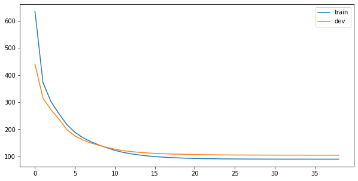

```python
fig = plt.figure(figsize=(10, 5))
ax = fig.add_subplot(111)
ax.plot(medium_train_data[0], label='train')
ax.plot(medium_train_data[1], label='dev')
ax.legend()
plt.show()
```

```python
medium_momentum_config = {
        'batch_size': 20, 'num_steps': 35,
        'num_layers': 2, 'emb_size': 650,
        'hidden_size': 650, 'vocab_size': 10001,
        'dropout_rate': 0.5, 'num_epochs': 39,
        'learning_rate': 1.0, 'lr_decay' : 0.9,
        'epoch_decay' : 10, 'tied_embs': False,
        'weight_init': 0.05, 'grad_clipping' : 5,
        'optimizer' : 'Momentum'
         }
```

```python
best_medium_model, mediumMom_train_data = train_on_config(medium_momentum_config)
```

```
PTBLM(
  (embedding): Embedding(10001, 650)
  (LSTM): LSTM(
    (layers): ModuleList(
      (0): Dropout(p=0.5, inplace=False)
      (1): LSTMLayer(
        (LSTMCell): LSTMCell()
      )
      (2): Dropout(p=0.5, inplace=False)
      (3): LSTMLayer(
        (LSTMCell): LSTMCell()
      )
      (4): Dropout(p=0.5, inplace=False)
    )
  )
  (decoder): Linear(in_features=650, out_features=10001, bias=True)
)
Training on device:  cuda:0
```

```
Epoch: 1. Learning rate: 1.000. Train Perplexity: 367.003. Dev Perplexity: 223.769.
Epoch: 2. Learning rate: 1.000. Train Perplexity: 197.540. Dev Perplexity: 163.970.
Epoch: 3. Learning rate: 1.000. Train Perplexity: 154.021. Dev Perplexity: 137.690.
Epoch: 4. Learning rate: 1.000. Train Perplexity: 130.067. Dev Perplexity: 121.907.
Epoch: 5. Learning rate: 1.000. Train Perplexity: 114.202. Dev Perplexity: 110.973.
Epoch: 6. Learning rate: 1.000. Train Perplexity: 102.295. Dev Perplexity: 103.803.
Epoch: 7. Learning rate: 1.000. Train Perplexity: 93.508. Dev Perplexity: 98.044.
Epoch: 8. Learning rate: 1.000. Train Perplexity: 86.204. Dev Perplexity: 94.622.
Epoch: 9. Learning rate: 1.000. Train Perplexity: 80.383. Dev Perplexity: 91.859.
Epoch: 10. Learning rate: 1.000. Train Perplexity: 75.276. Dev Perplexity: 89.566.
Epoch: 11. Learning rate: 0.900. Train Perplexity: 69.964. Dev Perplexity: 87.278.
Epoch: 12. Learning rate: 0.810. Train Perplexity: 65.419. Dev Perplexity: 85.503.
Epoch: 13. Learning rate: 0.729. Train Perplexity: 61.632. Dev Perplexity: 83.899.
Epoch: 14. Learning rate: 0.656. Train Perplexity: 58.359. Dev Perplexity: 83.604.
Epoch: 15. Learning rate: 0.590. Train Perplexity: 55.586. Dev Perplexity: 82.462.
Epoch: 16. Learning rate: 0.531. Train Perplexity: 53.023. Dev Perplexity: 81.735.
Epoch: 17. Learning rate: 0.478. Train Perplexity: 50.855. Dev Perplexity: 81.508.
Epoch: 18. Learning rate: 0.430. Train Perplexity: 49.059. Dev Perplexity: 80.952.
Epoch: 19. Learning rate: 0.387. Train Perplexity: 47.325. Dev Perplexity: 81.158.
Epoch: 20. Learning rate: 0.349. Train Perplexity: 45.859. Dev Perplexity: 80.947.
Epoch: 21. Learning rate: 0.314. Train Perplexity: 44.498. Dev Perplexity: 80.893.
Epoch: 22. Learning rate: 0.282. Train Perplexity: 43.353. Dev Perplexity: 80.685.
Epoch: 23. Learning rate: 0.254. Train Perplexity: 42.322. Dev Perplexity: 80.579.
Epoch: 24. Learning rate: 0.229. Train Perplexity: 41.382. Dev Perplexity: 80.534.
Epoch: 25. Learning rate: 0.206. Train Perplexity: 40.556. Dev Perplexity: 80.690.
Epoch: 26. Learning rate: 0.185. Train Perplexity: 39.776. Dev Perplexity: 80.567.
Epoch: 27. Learning rate: 0.167. Train Perplexity: 39.082. Dev Perplexity: 80.787.
Epoch: 28. Learning rate: 0.150. Train Perplexity: 38.580. Dev Perplexity: 80.820.
Epoch: 29. Learning rate: 0.135. Train Perplexity: 37.997. Dev Perplexity: 80.766.
Epoch: 30. Learning rate: 0.122. Train Perplexity: 37.516. Dev Perplexity: 80.734.
Epoch: 31. Learning rate: 0.109. Train Perplexity: 37.100. Dev Perplexity: 80.655.
Epoch: 32. Learning rate: 0.098. Train Perplexity: 36.713. Dev Perplexity: 80.680.
Epoch: 33. Learning rate: 0.089. Train Perplexity: 36.376. Dev Perplexity: 80.634.
Epoch: 34. Learning rate: 0.080. Train Perplexity: 36.013. Dev Perplexity: 80.638.
Epoch: 35. Learning rate: 0.072. Train Perplexity: 35.808. Dev Perplexity: 80.687.
Epoch: 36. Learning rate: 0.065. Train Perplexity: 35.499. Dev Perplexity: 80.541.
Epoch: 37. Learning rate: 0.058. Train Perplexity: 35.307. Dev Perplexity: 80.758.
Epoch: 38. Learning rate: 0.052. Train Perplexity: 35.107. Dev Perplexity: 80.575.
Epoch: 39. Learning rate: 0.047. Train Perplexity: 34.896. Dev Perplexity: 80.565.
Test Perplexity: 77.659
```

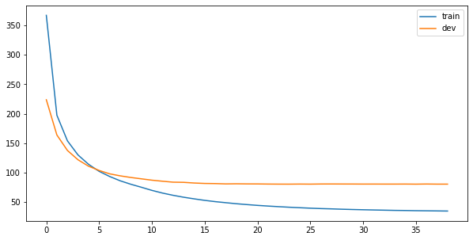

```python
fig = plt.figure(figsize=(10, 5))
ax = fig.add_subplot(111)
ax.plot(mediumMom_train_data[0], label='train')
ax.plot(mediumMom_train_data[1], label='dev')
ax.legend()
plt.show()
```

Ну и как видно, всё это было не зря. Удалось выбить достойные цифры для средней модели.  
Т.к. время поджимает, пока было принято решение оставить попытки выбивать лучшие результаты и пробовать большие модели. Но если останется время, то обязательно попробуем.

### Результаты из лидерборда:

Средняя модель из статьи Zaremba(обучалась 1 час на tesla P4)

```python
medium_config = { 'batch_size': 20, 'num_steps': 35,
           'num_layers': 2, 'emb_size': 650,
           'hidden_size': 650, 'vocab_size': -1,
           'dropout_rate': 0.5, 'num_epochs': 25,
           'learning_rate': 1.0, 'lr_decay' : 0.9,
           'epoch_decay' : 10, 'weight_init': 0.05,
           'grad_clipping':5,
           'optimizer':'Momentum'
         }
```

```
train 42.00
valid 94.91
test 91.41
```

Большая модель из статьи Zaremba, но с меньшим количеством эпох(обучалась 4 часа на tesla P4)

```python
big_config = { 'batch_size': 20, 'num_steps': 35,
           'num_layers': 2, 'emb_size': 1500,
           'hidden_size': 1500, 'vocab_size': -1,
           'dropout_rate': 0.65, 'num_epochs': 40,
           'learning_rate': 1.0, 'lr_decay' : 1.15,
           'epoch_decay' : 14, 'weight_init': 0.04,
           'grad_clipping': 10,
           'optimizer':'Momentum'
         }
```

```
train 43.26
valid 92.252
test 88.636
```

Добавив обычный Momentum SGD(не Nesterov) можно неплохо улучшить результат средней модели и скорее всего большой модели.

## 2.5 Генерация предложений

```python
def sentence_sampling(model, word_to_id, id_to_word, cnt = 1, temperature = 1.0, max_len = 20):

    device = torch.device("cuda:0" if torch.cuda.is_available() else "cpu")

    sentences = []
    for _ in range(cnt):
#         print(f"generating sentence #{_}")
        sent = []
        prev_word_idx = word_to_id[START_TOKEN]
        model.eval()
        with torch.no_grad():
            hidden_states = model.init_hidden(batch_size=1, device=device)
            for i in range(max_len):
                X = torch.tensor([[prev_word_idx]], dtype=torch.int64, device=device)
                logits, new_states = model(X, hidden_states)
                hidden_states = (new_states[0].detach(), new_states[1].detach())
                softmax = torch.nn.functional.softmax(logits, -1).cpu().numpy()[0, 0]
                if temperature != 1.0:
                    softmax = np.float_power(softmax, 1.0 / temperature)
                    softmax /= softmax.sum()
                prev_word_idx = np.random.choice(list(range(len(softmax))), p=softmax)
                sent.append(id_to_word[int(prev_word_idx)])

        sentences.append(' '.join(sent).split(EOS_TOKEN)[0])
    return sentences
```

#### Вопрос. Приведите по 10 примеров сгенерированных предложений при разных температурах.

```python
generated_sents_1 = sentence_sampling(base_model, word_to_id, id_to_word, cnt=10, temperature=1)
```

```python
for sent in generated_sents_1:
    print(sent)
```

```
chairman steven <unk> the bill for the irs directors age <unk> more <unk> owners ' antibody
an investment banker chairman alan <unk> vice president and chief operating officer in the other trade committee oct. n to
tariff devices in red leaders get theatrical swedish emergency service but the conference coup force decided to stay with a
consumer installment profits were n't expected
mr. hahn & co. said it would n't disclose it has been strong a n n increase by the results
macmillan bates also want to cut down the statutory loan for the <unk> machines and the whitbread spirits channel it
of the trust food industries scheduled to be considered the tax code in july
for the summer with sales $ n million
that a real system does he said
possible investigation of the women <unk> indicating a record to azt throughout adjusting periods and opposition into who could violate
```

```python
generated_sents_2 = sentence_sampling(base_model, word_to_id, id_to_word, cnt=10, temperature=0.5)
```

```python
for sent in generated_sents_2:
    print(sent)
```

```
the <unk> <unk> of the n <unk> is the <unk> <unk> of <unk> and the <unk> <unk> of <unk> <unk>
the buyer are n't interested in the <unk> of <unk>
the <unk> <unk> <unk> and <unk> <unk> <unk> <unk> <unk> <unk> <unk> <unk> <unk> <unk> <unk> a <unk> <unk> <unk>
the agreement with the bill is n't likely to <unk> the <unk> <unk> <unk> <unk> <unk> <unk> <unk> the <unk>
the n n <unk> and the <unk> <unk> the <unk> <unk> and <unk> are <unk>
<unk> the <unk> <unk> of <unk>
<unk> the <unk> <unk> <unk> <unk> in n n <unk> <unk> <unk> <unk> <unk> <unk> <unk> <unk> <unk> <unk> the
<unk> and the <unk> wine and political <unk> <unk> <unk>
the <unk> of <unk> the <unk> family has been <unk> to <unk> the <unk> <unk> <unk> the <unk> <unk> in
the company is <unk> a <unk> of <unk>
```

```python
generated_sents_3 = sentence_sampling(base_model, word_to_id, id_to_word, cnt=10, temperature=10)
```

```python
for sent in generated_sents_3:
    print(sent)
```

```
diesel anyone jersey he resource civil question purchase horrible barbara mile david action pitches emigration nationally crossland participant newsweek sang
hudson predicts withdrawals parcel enter turf orange abortion classic dominates expensive interesting consequences inventor revolving indonesia espn mci pile described
consistently cineplex pulled governments ball creatures overly s.c. leveraged confirmed pools master retire described contributions ventures result resolve improvement associates
larger charts united quantum family participate wayne replacement misleading sierra eaton comsat engelken joseph electric miami shareholder toronto short-term shift
highly neatly liberty jets state interviewed ehrlich manic capel owen debt builds matter voters bennett germans flavor tight consent years
testimony crush category produced junk-bond disciplinary pleasure stability dependent restaurants deposits fueled external circumstances reduced sectors treasurer own port quarter
intellectuals legally ca premier seattle mission pittston adjust positive expensive bringing <unk> taxpayers concentrate freeway proposals wine needs sends meaning
automatically pros bounced avoiding get centered trendy reluctance corporate movie spin deeply advanced dinner appealed topple reebok artists cell alice
names lose yankee intends hire quick well debris pure interest-rate thoughts campaigns carefully sport lawyer component cycling insiders responded defaulted
counties sold census tried generous owed cash democrats high prime hinted massive designed better campaign misleading inch security feb. suggest
```

Видим, что чем больше температура, тем более рандомными являются предложения.  
Это объясняется тем, что вероятности из софтмакса возводятся в степень меньше 1 и после нормировки маленькие числа становятся больше, а большИе меньше.

## 2.6 Tied input-output embeddings / Tied Softmax

В классе PTBLM уже реализованы связанные эмбеддинги, так что давайте попробуем их включить для базовой модели и посмотрим станет ли лучше?

```python
base_tied_config = {
        'batch_size': 64, 'num_steps': 35,
        'num_layers': 2, 'emb_size': 256,
        'hidden_size': 256, 'vocab_size': 10001,
        'dropout_rate': 0.2, 'num_epochs': 13,
        'learning_rate': 0.01, 'lr_decay' : 0.9,
        'epoch_decay' : 6, 'tied_embs': True,
        'weight_init':0.1, 'grad_clipping' : None,
        'optimizer' : 'Adam'
}
```

```python
base_tied_model, base_tied_train_data = train_on_config(base_tied_config)
```

```
PTBLM(
  (embedding): Embedding(10001, 256)
  (LSTM): LSTM(
    (layers): ModuleList(
      (0): Dropout(p=0.2, inplace=False)
      (1): LSTMLayer(
        (LSTMCell): LSTMCell()
      )
      (2): Dropout(p=0.2, inplace=False)
      (3): LSTMLayer(
        (LSTMCell): LSTMCell()
      )
      (4): Dropout(p=0.2, inplace=False)
    )
  )
  (decoder): Linear(in_features=256, out_features=10001, bias=True)
)
Training on device:  cuda:0
```

```
Epoch: 1. Learning rate: 0.010. Train Perplexity: 321.700. Dev Perplexity: 169.085.
Epoch: 2. Learning rate: 0.010. Train Perplexity: 149.745. Dev Perplexity: 128.473.
Epoch: 3. Learning rate: 0.010. Train Perplexity: 116.728. Dev Perplexity: 114.556.
Epoch: 4. Learning rate: 0.010. Train Perplexity: 101.592. Dev Perplexity: 109.239.
Epoch: 5. Learning rate: 0.010. Train Perplexity: 92.644. Dev Perplexity: 106.037.
Epoch: 6. Learning rate: 0.010. Train Perplexity: 86.267. Dev Perplexity: 104.096.
Epoch: 7. Learning rate: 0.009. Train Perplexity: 80.472. Dev Perplexity: 101.697.
Epoch: 8. Learning rate: 0.008. Train Perplexity: 75.538. Dev Perplexity: 101.135.
Epoch: 9. Learning rate: 0.007. Train Perplexity: 71.746. Dev Perplexity: 99.829.
Epoch: 10. Learning rate: 0.007. Train Perplexity: 68.260. Dev Perplexity: 99.173.
Epoch: 11. Learning rate: 0.006. Train Perplexity: 65.376. Dev Perplexity: 98.536.
Epoch: 12. Learning rate: 0.005. Train Perplexity: 63.142. Dev Perplexity: 98.324.
Epoch: 13. Learning rate: 0.005. Train Perplexity: 60.946. Dev Perplexity: 97.953.
Test Perplexity: 92.069
```

[figure not shown]

```python
fig = plt.figure(figsize=(20, 5))
ax = fig.add_subplot(121)
ax.plot(base_train_data[0], label='base')
ax.plot(base_tied_train_data[0], label='tied')
ax.set_title("Perplexity on train dataset.")
ax.legend()

ax2 = fig.add_subplot(122)
ax2.plot(base_train_data[1], label='base')
ax2.plot(base_tied_train_data[1], label='tied')
ax2.set_title("Perplexity on dev dataset.")
ax2.legend()

plt.show()
```

Тут можно заметить, что на тренировочных данных модели ведут себя примерно одинаково.  
Но на **dev** датасете мы замечаем, что модель со связанными эмбеддингами обучается быстрее и менее склонна к переобучению.  
(Базовая начинает переобучаться уже на 8 эпохе, а улучшенная не начала и на 13)

## 2.8 Text classification with LSTMs

Режим для классификации добавлен в модель в самом верху.

Теперь надо подготовить данные для обучения.

1) Загрузим данные.

```python
all_data = load_dataset_fast()
```

```
Loading train set
neg 7480
pos 7520
Loading dev set
neg 5020
pos 4980
Loading test set
unlabeled 25000
```

```python
my_stop_words = ['i', 'me', 'my', 'myself', 'we', 'our', 'ours', 'ourselves', 'you', "you're", "you've", "you'll",
                  "you'd", 'your', 'yours', 'yourself', 'yourselves', 'he', 'him', 'his', 'himself', 'she', "she's",
                  'her', 'hers', 'herself', 'it', "it's", 'its', 'itself', 'they', 'them', 'their', 'theirs',
                  'themselves', 'what', 'which', 'who', 'whom', 'this',
                  'that', "that'll", 'these', 'those', 'am', 'is', 'are', 'was', 'were', 'be', 'been', 'being', 'have',
                  'has', 'had', 'having', 'do', 'does', 'did', 'doing', 'a', 'an', 'the', 'and', 'but', 'if', 'or',
                  'because', 'as', 'until', 'while', 'of', 'at', 'by', 'for', 'with',
                  'about', 'against', 'between', 'into', 'through', 'during', 'before', 'after', 'above', 'below', 'to',
                  'from', 'up', 'down', 'in', 'out', 'on', 'off', 'over', 'under', 'again', 'further', 'then', 'once',
                  'here', 'there', 'when', 'where', 'why', 'how', 'all', 'any', 'both', 'each', 'few', 'more', 'most',
                  'other', 'some', 'such', 'no', 'nor', 'not', 'only', 'own', 'same', 'so', 'than', 'too', 'very', 's',
                  't', 'can', 'will', 'just', 'don', "don't", 'should', "should've", 'now', 'd', 'll', 'm', 'o', 're',
                  've', 'y', 'ain', 'aren', "aren't", 'could', 'couldn', "couldn't", 'didn', "didn't", 'doesn',
                  "doesn't", 'hadn', "hadn't", 'hasn', "hasn't", 'haven', "haven't", 'isn', "isn't", 'ma', 'mightn',
                  "mightn't", 'mustn', "mustn't", 'needn', "needn't", 'shan', "shan't", 'shouldn', "shouldn't", 'wasn',
                  "wasn't", 'weren', "weren't", 'won', "won't", 'wouldn', "wouldn't"]
```

```python
class Preprocessor:
    def __init__(self):
        self.allowed_words = None
        self.w2ind = None
        self.ind2w = None
        self.special_tokens = ['<start>', '<eos>', '<pad>']

    def preproc_one_(self, text):
        text = text.lower()
        remove_tags = re.compile(r'<.*?>')
        text = re.sub(remove_tags, '', text)
        text = text.translate(str.maketrans('', '', string.punctuation))
        text = ''.join(sym if (sym.isalnum() or sym in (" ", "'")) else f" {sym} " for sym in text)
        return text

    def preproc_(self, texts):
        return [self.preproc_one_(text) for text in texts]

    def tokenize_one_(self, text, stem=0):
        """
            arg: list of texts
            return: list of tokenized texts
        """

        tokenizer = re.compile(r"-?\d*[.,]?\d+|[?'\w]+|\S", re.MULTILINE | re.IGNORECASE)
        tokenized_text = tokenizer.findall(text)
        if stem == 0:
            return [token for token in tokenized_text if token not in my_stop_words]
        stem_text = [token[:stem] for token in tokenized_text if token not in my_stop_words]
        return stem_text

    def tokenize_(self, texts):
        return [self.tokenize_one_(text) for text in texts]

    def make_vocab_(self, texts):
        data = [token for text in texts for token in text]
        data += self.special_tokens

        counter = Counter(data)
        sorted_words = sorted(counter.items(), key=lambda x: -x[1])
        words = [w for w, _ in sorted_words]
        self.w2ind = dict(zip(words, range(len(words))))
        self.ind2w = {v: k for k, v in self.w2ind.items()}

    def fit_vocab(self, texts, max_df = 0.5, min_df = 5, min_tf = 5):

        tmp_texts = self.preproc_(texts)
        tmp_texts = self.tokenize_(tmp_texts)

        self.allowed_words = set()

        df_cnt = defaultdict(int)
        tf_cnt = defaultdict(int)
        total_documents = len(tmp_texts)
        for text in tmp_texts:
            been = set()
            for token in text:
                if token not in been:
                    been.add(token)
                    df_cnt[token] += 1
                tf_cnt[token] += 1

        for word, tf in tf_cnt.items():
            df = df_cnt[word]
            if tf >= min_tf and df / total_documents <= max_df and df >= min_df:
                self.allowed_words.add(word)

        transformed_texts = self.transform_texts(tmp_texts, inside=True)
        self.make_vocab_(transformed_texts)
        return self

    def transform_texts(self, texts, inside=False):


        if self.allowed_words is None:
            raise RuntimeError("Need to fit before transform")

        if not inside:
            texts = self.preproc_(texts)
            texts = self.tokenize_(texts)

        new_texts = []
        for text in texts:
            new_text = []
            for token in text:
                if token in self.allowed_words:
                    new_text.append(token)
                else:
                    new_text.append('<unk>')
            new_texts.append(new_text)
        return new_texts

    def texts_to_inds(self, texts, max_len=None, mode='sent'):

        """
            Transform list of tokenized texts to torch tensors, ready for sentiment analysis.
            Return:
                dataset_inds: torch.tensor with texts indices
                text_lenghts: torch.tensor with lenght of each text, needed for more precise predicting.

        """

        if self.w2ind is None:
            raise RuntimeError("Need to fit vocab before transform")


        if mode == 'lm':
            inds_texts = []
            for text in texts:
                cur_text = []
                for token in text:
                    cur_text.append(self.w2ind[token])
                inds_texts.append(cur_text)
            return inds_texts

        if max_len is None:
            max_len = max(len(text) for text in texts)

        text_lenghts = np.array([min(len(text), max_len) - 1 for text in texts])
        dataset_inds = np.full(shape=(len(texts), max_len), fill_value=self.w2ind['<pad>'], dtype=np.int32)
        for text_ind, text in enumerate(texts):
            for token_ind, token in enumerate(text):
                if token_ind >= max_len:
                    break
                dataset_inds[text_ind, token_ind] = self.w2ind[token]

        return torch.LongTensor(dataset_inds), torch.tensor(text_lenghts)
```

```python
train_dataset = all_data['train']
dev_dataset = all_data['dev']
test_dataset = all_data['test']
```

```python
train_texts, train_labels = train_dataset[1], train_dataset[2]
dev_texts, dev_labels = dev_dataset[1], dev_dataset[2]
```

```python
preprocessor = Preprocessor()
```

```python
print("START TEXTS PREPROCESSING")
start = time.time()
preprocessor = preprocessor.fit_vocab(train_texts, min_tf=3, min_df=3)
preprocessed_train_texts = preprocessor.transform_texts(train_texts)
preprocessed_dev_texts = preprocessor.transform_texts(dev_texts)
print(f"Finish preprocessing in {time.time() - start} seconds.")
```

```
START TEXTS PREPROCESSING
Finish preprocessing in 25.030214071273804 seconds.
```

```python
print(len(preprocessor.w2ind))
```

```
31141
```

```python
list(preprocessor.w2ind.items())[:50]
```

```
[('<unk>', 0),
 ('like', 1),
 ('good', 2),
 ('even', 3),
 ('would', 4),
 ('time', 5),
 ('story', 6),
 ('really', 7),
 ('see', 8),
 ('much', 9),
 ('well', 10),
 ('get', 11),
 ('also', 12),
 ('bad', 13),
 ('great', 14),
 ('people', 15),
 ('first', 16),
 ('dont', 17),
 ('made', 18),
 ('make', 19),
 ('way', 20),
 ('films', 21),
 ('movies', 22),
 ('characters', 23),
 ('think', 24),
 ('watch', 25),
 ('many', 26),
 ('two', 27),
 ('seen', 28),
 ('character', 29),
 ('never', 30),
 ('little', 31),
 ('best', 32),
 ('love', 33),
 ('plot', 34),
 ('acting', 35),
 ('life', 36),
 ('know', 37),
 ('show', 38),
 ('ever', 39),
 ('better', 40),
 ('end', 41),
 ('still', 42),
 ('man', 43),
 ('say', 44),
 ('scene', 45),
 ('scenes', 46),
 ('go', 47),
 ('something', 48),
 ('back', 49)]
```

```python
preprocessed_train_texts[1]
```

```
['gave',
 '<unk>',
 '10',
 'needed',
 'rewarded',
 'scary',
 'elements',
 'actors',
 'god',
 '<unk>',
 'thing',
 'dont',
 'want',
 'tell',
 'anyone',
 'anything',
 'acting',
 'story',
 'ruin',
 '<unk>',
 'recommend',
 'go',
 'straight',
 'nearest',
 '<unk>',
 'right',
 'rent',
 'dont',
 'forget',
 'popcorn']
```

Теперь преобразуем тексты в выровненные массивы индексов.  
Но сначала соберём статистику о длине текстов.

```python
def dataset_stat(texts):
    lenghts = np.array(sorted([len(text) for text in texts]))
    min_len = min(lenghts)
    max_len = max(lenghts)
    median = lenghts[len(lenghts) // 2]
    mean = lenghts.mean()

    print("min_len = ", min_len)
    print("max_len = ", max_len)
    print("median = ", median)
    print("mean = ", mean)
    plt.hist(lenghts, bins=50)
    plt.show()
```

```
min_len =  4
max_len =  927
median =  91
mean =  122.3146
```

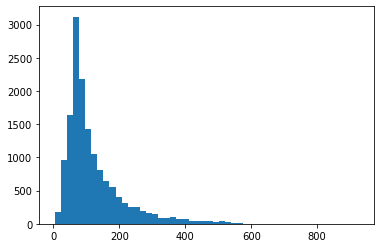

```python
dataset_stat(preprocessed_train_texts)
```

```
min_len =  9
max_len =  1425
median =  88
mean =  119.2318
```

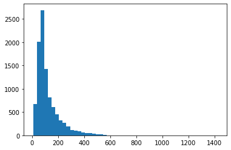

```python
dataset_stat(preprocessed_dev_texts)
```

Максимальная длина отзыва очень большая и модель будет работать очень долго с такими большими текстами. Поэтому попробуем максимальную длину предложения в 200-300 слов, а все бОльшие обрежем до этого размера. Конечно это должно работать хуже, но сильно быстрее.

```python
def texts_to_inds(texts, w2ind, max_len=None):


    if max_len is None:
        max_len = max(len(text) for text in texts)

    text_lenghts = np.array([min(len(text), max_len) - 1 for text in texts])
    dataset_inds = np.full(shape=(len(texts), max_len), fill_value=w2ind['<pad>'], dtype=np.int32)
    for text_ind, text in enumerate(texts):
        for token_ind, token in enumerate(text):
            if token_ind >= max_len:
                break
            try:
                dataset_inds[text_ind, token_ind] = w2ind[token]
            except KeyError as err:
                print(f"text #{text_ind}")
                print(text)
                raise KeyError

    return torch.LongTensor(dataset_inds), torch.tensor(text_lenghts)
```

```python
X_train, train_text_lenghts = texts_to_inds(preprocessed_train_texts, preprocessor.w2ind, max_len=200)
X_dev, dev_text_lenghts = texts_to_inds(preprocessed_dev_texts, preprocessor.w2ind, max_len=200)
```

```python
X_train.shape, X_dev.shape
```

```
(torch.Size([15000, 200]), torch.Size([10000, 200]))
```

А сейчас запихнём тексты их длины и лейблы в даталоадер

```python
y_train = torch.tensor([int(lab == 'pos') for lab in train_labels])
y_dev = torch.tensor([int(lab == 'pos') for lab in dev_labels])
```

```python
train_dataset = TensorDataset(X_train, y_train, train_text_lenghts)
dev_dataset = TensorDataset(X_dev, y_dev, dev_text_lenghts)
```

```python
train_dataset[0]
```

```
(tensor([ 6432,  2614,  1767,  5168,     4,  1615,  1239,   456,   258,     4,
           287,  8273,     0,    54,    13,  1943,    73,  5168,  1227,    31,
          1348,   117, 13392,  3064,  1767,     4,   407,     0,   888,  4998,
          5916,   624,     0,  3613,  1439,   878,   840,   692,  1856, 15149,
            18,  3039, 15150,  3263,     0,     6,  4912,   775,  3539,  1920,
          1703,     7,  4999,    80,  3497,   347,  2614,  1012,   975,  1177,
             0,  1103, 15149,   147,  2793,    70,  1583,  5469, 16296, 13393,
          9161,   209,    68,   744,   116,  2327,    53,   921,  1583,   284,
            62,   125,  2719,   927,  1142,    24,  1767,   135,    64, 23562,
          8027,   645,  4394,   508, 17598,    98,  1405, 12677,  1767,  4601,
           207,     0,   113,   452,  1143,   438,  5917,  2740, 14201,  1748,
          3153,  5362, 17599,   105,    99,  1164,  1401,  2263,   581,  5917,
          2815,  1704,   400,  1013,  2740,  1246,  1497,  1316,  1749,  1704,
           234,  1040,  1444,  2816,  2856,   264,   400,  1616,   494,  1402,
         11559,  5917,   586,     1,   105,  3065,  2659,    50,  2455,  1421,
          1577,  6699, 15151,  1616,   282,  7234,   401,  2413,  1444, 14202,
         23563,  1616,     7,  2263,  3714,  1393,    85,  2676,  1856, 15149,
           276, 19205,  1218,  3806,   792,   117,   374,   856,  2677,  3308,
          1767,   242,  3090,  3039,   639,   244,   421,     0,   109,  1126,
          1093,  3224,  2151,   182,  1617,  6307,   121, 11560,   212,   960]),
 tensor(0),
 tensor(199))
```

Теперь можно делать функции для обучения

```python
def sent_run_epoch(
    lr,
    model,
    loss_fn,
    batch_size,
    dataloader,
    optimizer = None,
    clip_value = None,
    device = None
) -> float:
    '''
    Performs one training epoch or inference epoch
    Args:
        lr: Learning rate for this epoch
        model: Language model object
        dataloader: pytorch Dataloader with (text, label, len) examples
        word_to_id: Mapping of each word into its index in the vocabulary
        loss_fn: Torch loss function
        optimizer: Torch optimizer
        device: Input tensors should be sent to this device
    Returns:
        Accuracy
    '''
    total_loss, total_examples = 0.0, 0
    total_correct = 0



    for step, (X_batch, Y_batch, len_batch) in enumerate(dataloader):

        initial_state = model.init_hidden(batch_size=X_batch.shape[0], device=device)

        X = X_batch.to(device)
        Y = Y_batch.to(device)
        lenghts = len_batch.to(device)

        logits, new_state = model.forward_classify(X, lenghts, initial_state)

        loss = loss_fn(logits, Y.view(-1))
        total_examples += loss.size(0)
        total_loss += loss.sum().item()
        loss = loss.mean()

        _, predicted = torch.max(logits, 1)
        predicted = predicted.cpu()
        total_correct += (Y_batch == predicted).sum().item()

        # Gradients computation
        if optimizer is not None:
            loss.backward()

            # We have a new learning rate value at every step, so it needs to be updated
            update_lr(optimizer, lr)

            # Gradient clipping by predefined norm value - usually 5.0
            if clip_value is not None:
                torch.nn.utils.clip_grad_norm_(model.parameters(), clip_value)

            # Applying gradients - one gradient descent step
            optimizer.step()
            optimizer.zero_grad()
#         print("train loss: ", total_loss / total_examples)

    return total_loss/total_examples, total_correct / total_examples
```

```python
def train_sent_on_config(sent_config, pretrained_model=None):
    if pretrained_model is not None:
        model = copy.deepcopy(pretrained_model)
    else:
        model = PTBLM(num_layers=sent_config['num_layers'], emb_size=sent_config['emb_size'],
              hidden_size=sent_config['hidden_size'], vocab_size=sent_config['vocab_size'],
              dropout_rate=sent_config['dropout_rate'], weight_init=sent_config['weight_init'],
              tie_emb=sent_config['tied_embs']
             )
    print(model)
    device = torch.device("cuda:0" if torch.cuda.is_available() else "cpu")
    print("Training on device: ", device)
    model.to(device)

    loss_fn = torch.nn.CrossEntropyLoss(reduction='none')

    if sent_config['optimizer'] == 'Adam':
        optimizer = torch.optim.Adam(model.parameters(), lr=sent_config['learning_rate'])
    elif sent_config['optimizer'] == 'SGD':
        optimizer = torch.optim.SGD(model.parameters(), lr=sent_config['learning_rate'])
    else:
        optimizer = torch.optim.SGD(model.parameters(), lr=sent_config['learning_rate'], momentum=0.8)

    acc_plot_data = [[], []]
    loss_plot_data = [[], []]

    for i in trange(sent_config['num_epochs']):

        train_dataloader = DataLoader(train_dataset, batch_size=sent_config['batch_size'], shuffle=True)
        dev_dataloader = DataLoader(dev_dataset, batch_size=sent_config['batch_size'], shuffle=True)

        lr_decay = sent_config['lr_decay'] ** max(i + 1 - sent_config['epoch_decay'], 0.0)
        if sent_config['lr_decay'] > 1:
            lr_decay = 1 / lr_decay
        decayed_lr = sent_config['learning_rate'] * lr_decay


        model.train()
        train_loss, train_acc = sent_run_epoch(decayed_lr, model,
                                     loss_fn,
                                     dataloader=train_dataloader,
                                     batch_size=sent_config['batch_size'],
                                     optimizer=optimizer,
                                     clip_value=sent_config['grad_clipping'],
                                     device=device)

        model.eval()

        # Disabling gradient calculation.
        # It will reduce memory consumption for computations
        # The result of every computation will have requires_grad=False,

        with torch.no_grad():
            dev_loss, dev_acc = sent_run_epoch(decayed_lr, model,
                                               loss_fn,
                                               dataloader=dev_dataloader,
                                               batch_size=sent_config['batch_size'],
                                               clip_value=sent_config['grad_clipping'],
                                               device=device)

        acc_plot_data[0].append(train_acc)
        acc_plot_data[1].append(dev_acc)
        loss_plot_data[0].append(train_loss)
        loss_plot_data[1].append(dev_loss)
        print(f'Epoch: {i+1}. Learning rate: {decayed_lr}. '
              f'Train Acc: {train_acc:.3f}. '
              f'Train Loss: {train_loss:.3f}. '
              f'Dev Acc: {dev_acc:.3f}. '
              f'Dev Loss: {dev_loss:.3f}. '
             )
    return acc_plot_data, loss_plot_data
```

```python
imdb_base_config = {
        'batch_size': 256,'num_layers': 1,
        'emb_size': 256, 'hidden_size': 256,
        'vocab_size': len(preprocessor.w2ind),
        'dropout_rate': 0.65, 'num_epochs': 6,
        'learning_rate': 0.0005, 'lr_decay' : 0.8,
        'epoch_decay' : 4, 'tied_embs': False,
        'weight_init':0.1, 'grad_clipping' : None,
        'optimizer' : 'Adam'
}
imdb_base_config['vocab_size']
```

```
31141
```

```python
base_sent_acc, base_sent_loss = train_sent_on_config(imdb_base_config)
```

```
PTBLM(
  (embedding): Embedding(31141, 256)
  (LSTM): LSTM(
    (layers): ModuleList(
      (0): Dropout(p=0.65, inplace=False)
      (1): LSTMLayer(
        (LSTMCell): LSTMCell()
      )
      (2): Dropout(p=0.65, inplace=False)
    )
  )
  (decoder): Linear(in_features=256, out_features=31141, bias=True)
  (adaptive_sm): AdaptiveLogSoftmaxWithLoss(
    (head): Linear(in_features=256, out_features=503, bias=False)
    (tail): ModuleList(
      (0): Sequential(
        (0): Linear(in_features=256, out_features=64, bias=False)
        (1): Linear(in_features=64, out_features=1500, bias=False)
      )
      (1): Sequential(
        (0): Linear(in_features=256, out_features=16, bias=False)
        (1): Linear(in_features=16, out_features=8000, bias=False)
      )
      (2): Sequential(
        (0): Linear(in_features=256, out_features=4, bias=False)
        (1): Linear(in_features=4, out_features=21141, bias=False)
      )
    )
  )
  (sentiment_decoder): Linear(in_features=256, out_features=2, bias=True)
)
Training on device:  cuda:0
```

```
Epoch: 1. Learning rate: 0.0005. Train Acc: 0.535. Train Loss: 0.691. Dev Acc: 0.678. Dev Loss: 0.673.
Epoch: 2. Learning rate: 0.0005. Train Acc: 0.747. Train Loss: 0.563. Dev Acc: 0.851. Dev Loss: 0.384.
Epoch: 3. Learning rate: 0.0005. Train Acc: 0.891. Train Loss: 0.279. Dev Acc: 0.866. Dev Loss: 0.316.
Epoch: 4. Learning rate: 0.0005. Train Acc: 0.929. Train Loss: 0.197. Dev Acc: 0.876. Dev Loss: 0.299.
Epoch: 5. Learning rate: 0.0004. Train Acc: 0.956. Train Loss: 0.130. Dev Acc: 0.883. Dev Loss: 0.302.
Epoch: 6. Learning rate: 0.0003200000000000001. Train Acc: 0.968. Train Loss: 0.094. Dev Acc: 0.879. Dev Loss: 0.367.
```

[figure not shown]

```python
fig = plt.figure(figsize=(20, 5))
ax = fig.add_subplot(121)
ax.plot(base_sent_acc[0], label='train')
ax.plot(base_sent_acc[1], label='dev')
ax.set_title("Accuracy.")
ax.legend()

ax2 = fig.add_subplot(122)
ax2.plot(base_sent_loss[0], label='train')
ax2.plot(base_sent_loss[1], label='dev')
ax2.set_title("Loss.")
ax2.legend()

plt.show()
```

Вот как-то так при рандомном конфиге можно увидеть, что модель быстро переобучается, но можно выбить **88% accuracy**. Этот результат будет сложно побить...  
Но попробуем подобрать другие параметры обучения.

```python
imdb_baseV2_config = {
        'batch_size': 256,'num_layers': 1,
        'emb_size': 650, 'hidden_size': 650,
        'vocab_size': len(preprocessor.w2ind),
        'dropout_rate': 0.65, 'num_epochs': 8,
        'learning_rate': 0.0005, 'lr_decay' : 0.5,
        'epoch_decay' : 4, 'tied_embs': False,
        'weight_init':0.1, 'grad_clipping' : None,
        'optimizer' : 'Adam'
}
imdb_baseV2_config['vocab_size']
```

```
31141
```

```python
baseV2_sent_acc, baseV2_sent_loss = train_sent_on_config(imdb_baseV2_config)
```

[output not shown]

[output not shown]

[figure not shown]

```python
fig = plt.figure(figsize=(20, 5))
ax = fig.add_subplot(121)
ax.plot(baseV2_sent_acc[0], label='train')
ax.plot(baseV2_sent_acc[1], label='dev')
ax.set_title("Accuracy.")
ax.legend()

ax2 = fig.add_subplot(122)
ax2.plot(baseV2_sent_loss[0], label='train')
ax2.plot(baseV2_sent_loss[1], label='dev')
ax2.set_title("Loss.")
ax2.legend()

plt.show()
```

По итогу ничего не вышло, ну и ладно. В целом это неплохой результат для базовой модели. Оставим пока всё как есть

## 2.9 Pre-training LSTMs for text classification

Теперь попробуем использовать в качестве начальной модели предобученую модель для задачи language modelling.

Сначала нам нужно приготовить данные для предобучения.

```python
def add_start(texts, w2ind):
    lm_texts = []
    for text in texts:
        new_text = ['<start>'] + text
        lm_texts.append(new_text)

    return lm_texts
```

```python
imdb_LM_train = preprocessed_train_texts[:]
imdb_LM_dev = preprocessed_dev_texts[:]
imdb_LM_train = add_start(imdb_LM_train, preprocessor.w2ind)
imdb_LM_dev = add_start(imdb_LM_dev, preprocessor.w2ind)
imdb_LM_dev[0][:20]
```

```
['<start>',
 'first',
 'say',
 'worked',
 'blockbuster',
 'seen',
 'quite',
 'movies',
 'point',
 'tough',
 'find',
 'something',
 'havent',
 'seen',
 'taking',
 'account',
 'want',
 'everyone',
 'know',
 '<unk>']
```

```python
imdb_LM_train = _sentences_to_word_ids(preprocessor.w2ind, texts=imdb_LM_train)
imdb_LM_dev = _sentences_to_word_ids(preprocessor.w2ind, texts=imdb_LM_dev)
```

```python
for sent in imdb_LM_train[:2]:
    print(sent)
```

```
[31138, 6432, 2614, 1767, 5168, 4, 1615, 1239, 456, 258, 4, 287, 8273, 0, 54, 13, 1943, 73, 5168, 1227, 31, 1348, 117, 13392, 3064, 1767, 4, 407, 0, 888, 4998, 5916, 624, 0, 3613, 1439, 878, 840, 692, 1856, 15149, 18, 3039, 15150, 3263, 0, 6, 4912, 775, 3539, 1920, 1703, 7, 4999, 80, 3497, 347, 2614…
[31138, 398, 0, 183, 745, 7235, 533, 653, 56, 428, 0, 55, 17, 83, 232, 145, 125, 35, 6, 2123, 0, 266, 47, 672, 8546, 0, 103, 757, 17, 723, 3498]
```

```python
def train_IMDBLM_on_config(cur_config):
    model = PTBLM(num_layers=cur_config['num_layers'], emb_size=cur_config['emb_size'],
              hidden_size=cur_config['hidden_size'], vocab_size=cur_config['vocab_size'],
              dropout_rate=cur_config['dropout_rate'], weight_init=cur_config['weight_init'],
              tie_emb=cur_config['tied_embs'], adaptive=cur_config['adaptive']
             )
    print(model)
    device = torch.device("cuda:0" if torch.cuda.is_available() else "cpu")
    print("Training on device: ", device)
    model.to(device)

    loss_fn = torch.nn.CrossEntropyLoss(reduction='none')

    loss_fn = loss_fn.to(device)

    if cur_config['optimizer'] == 'Adam':
        optimizer = torch.optim.Adam(model.parameters(), lr=cur_config['learning_rate'])
    elif cur_config['optimizer'] == 'SGD':
        optimizer = torch.optim.SGD(model.parameters(), lr=cur_config['learning_rate'])
    else:
        optimizer = torch.optim.SGD(model.parameters(), lr=cur_config['learning_rate'], momentum=0.8)


    plot_data = [[], []]
    for i in trange(cur_config['num_epochs']):
        lr_decay = cur_config['lr_decay'] ** max(i + 1 - cur_config['epoch_decay'], 0.0)
        if cur_config['lr_decay'] > 1:
            lr_decay = 1 / lr_decay
        decayed_lr = cur_config['learning_rate'] * lr_decay

        model.train()
        train_perplexity = run_epoch(decayed_lr, model, imdb_LM_train,
                                     word_to_id, loss_fn,
                                     cur_config['batch_size'], cur_config['num_steps'],
                                     optimizer=optimizer,
                                     clip_value=cur_config['grad_clipping'],
                                     device=device)

        model.eval()

        # Disabling gradient calculation.
        # It will reduce memory consumption for computations
        # The result of every computation will have requires_grad=False,
        with torch.no_grad():
            dev_perplexity = run_epoch(decayed_lr, model, imdb_LM_dev,
                                       word_to_id, loss_fn, cur_config['batch_size'], cur_config['num_steps'],
                                       device=device)

        plot_data[0].append(train_perplexity)
        plot_data[1].append(dev_perplexity)
        print(f'Epoch: {i+1}. Learning rate: {decayed_lr:.3f}. '
              f'Train Perplexity: {train_perplexity:.3f}. '
              f'Dev Perplexity: {dev_perplexity:.3f}. '
             )

    model.eval()
#     with torch.no_grad():
#         test_perplexity = run_epoch(
#             decayed_lr, model, test_data,
#             word_to_id, loss_fn, cur_config['batch_size'], cur_config['num_steps'],
#             device=device)
#         print(f"Test Perplexity: {test_perplexity:.3f}")

    return model, plot_data
```

```python
base_IMDBLM_config = {
        'batch_size': 20, 'num_steps': 35,
        'num_layers': 2, 'emb_size': 256,
        'hidden_size': 256, 'vocab_size': len(preprocessor.w2ind),
        'dropout_rate': 0.5, 'num_epochs': 13,
        'learning_rate': 0.005, 'lr_decay' : 0.9,
        'epoch_decay' : 6, 'tied_embs': True,
        'weight_init':0.1, 'grad_clipping' : 5,
        'adaptive':True,
        'optimizer' : 'Adam'
}
```

```python
IMDBLM_base_model, IMDBLM_data = train_IMDBLM_on_config(base_IMDBLM_config)
```

```
PTBLM(
  (embedding): Embedding(31141, 256)
  (LSTM): LSTM(
    (layers): ModuleList(
      (0): Dropout(p=0.5, inplace=False)
      (1): LSTMLayer(
        (LSTMCell): LSTMCell()
      )
      (2): Dropout(p=0.5, inplace=False)
      (3): LSTMLayer(
        (LSTMCell): LSTMCell()
      )
      (4): Dropout(p=0.5, inplace=False)
    )
  )
  (decoder): Linear(in_features=256, out_features=31141, bias=True)
  (adaptive_sm): AdaptiveLogSoftmaxWithLoss(
    (head): Linear(in_features=256, out_features=503, bias=False)
    (tail): ModuleList(
      (0): Sequential(
        (0): Linear(in_features=256, out_features=64, bias=False)
        (1): Linear(in_features=64, out_features=1500, bias=False)
      )
      (1): Sequential(
        (0): Linear(in_features=256, out_features=16, bias=False)
        (1): Linear(in_features=16, out_features=8000, bias=False)
      )
      (2): Sequential(
        (0): Linear(in_features=256, out_features=4, bias=False)
        (1): Linear(in_features=4, out_features=21141, bias=False)
      )
    )
  )
  (sentiment_decoder): Linear(in_features=256, out_features=2, bias=True)
)
Training on device:  cuda:0
```

[output not shown]

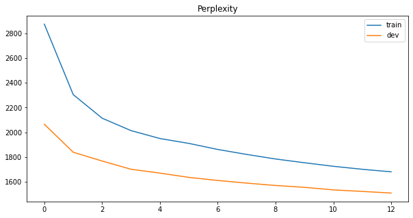

```python
fig = plt.figure(figsize=(10, 5))
ax = fig.add_subplot(111)
ax.plot(IMDBLM_data[0], label='train')
ax.plot(IMDBLM_data[1], label='dev')
ax.set_title("Perplexity")
ax.legend()
plt.show()
```

```python
baseV2_IMDBLM_config = {
        'batch_size': 64, 'num_steps': 35,
        'num_layers': 2, 'emb_size': 650,
        'hidden_size': 650, 'vocab_size': len(preprocessor.w2ind),
        'dropout_rate': 0.5, 'num_epochs': 15,
        'learning_rate': 0.001, 'lr_decay' : 0.9,
        'epoch_decay' : 6, 'tied_embs': False,
        'weight_init': 0.05, 'grad_clipping' : 5,
        'adaptive' : True,
        'optimizer' : 'Adam'
}
```

```python
baseV2_IMDBLM_base_model, baseV2_IMDBLM_data = train_IMDBLM_on_config(baseV2_IMDBLM_config)
```

```
PTBLM(
  (embedding): Embedding(31141, 650)
  (LSTM): LSTM(
    (layers): ModuleList(
      (0): Dropout(p=0.5, inplace=False)
      (1): LSTMLayer(
        (LSTMCell): LSTMCell()
      )
      (2): Dropout(p=0.5, inplace=False)
      (3): LSTMLayer(
        (LSTMCell): LSTMCell()
      )
      (4): Dropout(p=0.5, inplace=False)
    )
  )
  (decoder): Linear(in_features=650, out_features=31141, bias=True)
  (adaptive_sm): AdaptiveLogSoftmaxWithLoss(
    (head): Linear(in_features=650, out_features=503, bias=False)
    (tail): ModuleList(
      (0): Sequential(
        (0): Linear(in_features=650, out_features=162, bias=False)
        (1): Linear(in_features=162, out_features=1500, bias=False)
      )
      (1): Sequential(
        (0): Linear(in_features=650, out_features=40, bias=False)
        (1): Linear(in_features=40, out_features=8000, bias=False)
      )
      (2): Sequential(
        (0): Linear(in_features=650, out_features=10, bias=False)
        (1): Linear(in_features=10, out_features=21141, bias=False)
      )
    )
  )
  (sentiment_decoder): Linear(in_features=650, out_features=2, bias=True)
)
Training on device:  cuda:0
```

```
Epoch: 1. Learning rate: 0.001. Train Perplexity: 2996.549. Dev Perplexity: 2209.729.
Epoch: 2. Learning rate: 0.001. Train Perplexity: 2226.628. Dev Perplexity: 1819.915.
Epoch: 3. Learning rate: 0.001. Train Perplexity: 1891.638. Dev Perplexity: 1639.656.
Epoch: 4. Learning rate: 0.001. Train Perplexity: 1681.386. Dev Perplexity: 1531.342.
Epoch: 5. Learning rate: 0.001. Train Perplexity: 1530.537. Dev Perplexity: 1465.127.
Epoch: 6. Learning rate: 0.001. Train Perplexity: 1412.544. Dev Perplexity: 1417.815.
Epoch: 7. Learning rate: 0.001. Train Perplexity: 1309.783. Dev Perplexity: 1386.423.
Epoch: 8. Learning rate: 0.001. Train Perplexity: 1225.277. Dev Perplexity: 1367.246.
Epoch: 9. Learning rate: 0.001. Train Perplexity: 1158.412. Dev Perplexity: 1358.704.
Epoch: 10. Learning rate: 0.001. Train Perplexity: 1103.853. Dev Perplexity: 1350.903.
Epoch: 11. Learning rate: 0.001. Train Perplexity: 1056.357. Dev Perplexity: 1349.132.
Epoch: 12. Learning rate: 0.001. Train Perplexity: 1016.803. Dev Perplexity: 1350.453.
Epoch: 13. Learning rate: 0.000. Train Perplexity: 982.335. Dev Perplexity: 1351.665.
Epoch: 14. Learning rate: 0.000. Train Perplexity: 952.783. Dev Perplexity: 1355.872.
Epoch: 15. Learning rate: 0.000. Train Perplexity: 925.955. Dev Perplexity: 1362.255.
```

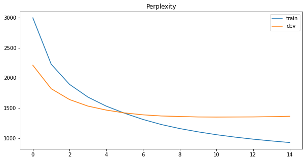

```python
fig = plt.figure(figsize=(10, 5))
ax = fig.add_subplot(111)
ax.plot(baseV2_IMDBLM_data[0], label='train')
ax.plot(baseV2_IMDBLM_data[1], label='dev')
ax.set_title("Perplexity")
ax.legend()
plt.show()
```

```python
imdb_sentLM_config = {
        'batch_size': 256,'num_layers': 2,
        'emb_size': 650, 'hidden_size': 650,
        'vocab_size': len(preprocessor.w2ind),
        'dropout_rate': 0.65, 'num_epochs': 6,
        'learning_rate': 0.003, 'lr_decay' : 0.8,
        'epoch_decay' : 4, 'tied_embs': False,
        'weight_init':0.1, 'grad_clipping' : 5,
        'optimizer' : 'Adam'
}
imdb_sentLM_config['vocab_size']
```

```
31141
```

```python
train_sent_base_acc, train_sent_base_loss = train_sent_on_config(imdb_sentLM_config, pretrained_model=IMDBLM_base_model)
```

```
PTBLM(
  (embedding): Embedding(31141, 256)
  (LSTM): LSTM(
    (layers): ModuleList(
      (0): Dropout(p=0.5, inplace=False)
      (1): LSTMLayer(
        (LSTMCell): LSTMCell()
      )
      (2): Dropout(p=0.5, inplace=False)
      (3): LSTMLayer(
        (LSTMCell): LSTMCell()
      )
      (4): Dropout(p=0.5, inplace=False)
    )
  )
  (decoder): Linear(in_features=256, out_features=31141, bias=True)
  (adaptive_sm): AdaptiveLogSoftmaxWithLoss(
    (head): Linear(in_features=256, out_features=503, bias=False)
    (tail): ModuleList(
      (0): Sequential(
        (0): Linear(in_features=256, out_features=64, bias=False)
        (1): Linear(in_features=64, out_features=1500, bias=False)
      )
      (1): Sequential(
        (0): Linear(in_features=256, out_features=16, bias=False)
        (1): Linear(in_features=16, out_features=8000, bias=False)
      )
      (2): Sequential(
        (0): Linear(in_features=256, out_features=4, bias=False)
        (1): Linear(in_features=4, out_features=21141, bias=False)
      )
    )
  )
  (sentiment_decoder): Linear(in_features=256, out_features=2, bias=True)
)
Training on device:  cuda:0
```

```
Epoch: 1. Learning rate: 0.003. Train Acc: 0.731. Train Loss: 0.571. Dev Acc: 0.796. Dev Loss: 0.450.
Epoch: 2. Learning rate: 0.003. Train Acc: 0.811. Train Loss: 0.435. Dev Acc: 0.825. Dev Loss: 0.394.
Epoch: 3. Learning rate: 0.003. Train Acc: 0.834. Train Loss: 0.383. Dev Acc: 0.845. Dev Loss: 0.362.
Epoch: 4. Learning rate: 0.003. Train Acc: 0.852. Train Loss: 0.348. Dev Acc: 0.855. Dev Loss: 0.344.
Epoch: 5. Learning rate: 0.0024000000000000002. Train Acc: 0.867. Train Loss: 0.319. Dev Acc: 0.862. Dev Loss: 0.332.
Epoch: 6. Learning rate: 0.0019200000000000005. Train Acc: 0.877. Train Loss: 0.297. Dev Acc: 0.864. Dev Loss: 0.332.
```

```python
base_sent_acc
```

```
[[0.5348666666666667, 0.7474, 0.8912, 0.9288, 0.9557333333333333, 0.9684],
 [0.6777, 0.851, 0.8664, 0.8762, 0.883, 0.8789]]
```

```python
train_sent_base_acc
```

```
[[0.7310666666666666,
  0.8106666666666666,
  0.8344666666666667,
  0.8515333333333334,
  0.8669333333333333,
  0.8768666666666667],
 [0.7956, 0.8254, 0.8454, 0.8554, 0.8618, 0.8635]]
```

[figure not shown]

```python
fig = plt.figure(figsize=(20, 5))
ax = fig.add_subplot(121)
ax.plot(train_sent_base_acc[0], label='train')
ax.plot(train_sent_base_acc[1], label='dev')
ax.set_title("Accuracy With pretraining.")
ax.legend()



ax2 = fig.add_subplot(122)
ax2.plot(base_sent_acc[0], label='train')
ax2.plot(base_sent_acc[1], label='dev')
ax2.set_title("Accuracy Without pretraining")
ax2.legend()

plt.show()
```

Можно заметить, что модель с предобучением менее склонна к переобучению и получает более высокие результаты в начале обучения.

#### Лучшие модели

По результатам экспериментов с тестирующим скриптом получилось следующее:

Лучший конфиг для LSTM сети без предобучения:

```python
imdb_baseV2_config = {
        'batch_size': 256,'num_layers': 1,
        'emb_size': 650, 'hidden_size': 650,
        'vocab_size': len(preprocessor.w2ind),
        'dropout_rate': 0.65, 'num_epochs': 8,
        'learning_rate': 0.0005, 'lr_decay' : 0.5,
        'epoch_decay' : 4, 'tied_embs': False,
        'weight_init':0.1, 'grad_clipping' : None,
        'optimizer' : 'Adam'
}
imdb_baseV2_config['vocab_size']
```

```
31141
```

Лучше контролируется переобучение, чем на двухслойной модели и достигает 88 процентов точности.

Лучший конфиг для предобучаемой сети:

```python
# Для модели и предобучения на IMDB
lm_config = {
        'batch_size': 256, 'num_steps': 35,
        'num_layers': 2, 'emb_size': 650,
        'hidden_size': 650, 'vocab_size': -1,
        'dropout_rate': 0.65, 'num_epochs': 10,
        'learning_rate': 0.005, 'lr_decay' : 0.8,
        'epoch_decay' : 8, 'tied_embs': False,
        'weight_init': 0.05, 'grad_clipping' : 5,
        'optimizer' : 'Adam',
        'adaptive' : True
         }
```

В целом обучить языковую модель с хорошей перплексией на IMDB оказалось тяжело, минимальная получалась в районе ~1300 при словаре на 60000 слов. У этого конфига ~1600 на 60000 слов.

```python
# Для обучения определения тональностей на IMDB
sent_config = {
        'batch_size' : 256,
        'vocab_size': -1,
        'dropout_rate' : 0.65, 'num_epochs' : 5,
        'learning_rate': 0.0005, 'lr_decay' : 0.5,
        'epoch_decay' : 3, 'grad_clipping' : 5,
        'optimizer' : 'Adam'
        }
```

Но предобучение действительно даёт свои плоды, модель меньше переобучается и стартует первую с большей точности. (~82%) Если подкрутить параметры (или добавить валидационный датасет XD), то точно можно выбить 90+.

Этот конфиг получает следующие результаты в лидерборде:

```
train: 95.97
dev: 89.58
dev-b: 76.65
```